# UNIVERSIDAD NACIONAL AUTÓNOMA DE MÉXICO

MATEMÁTICAS APLICADAS Y COMPUTACIÓN

Luján García César Alejandro Gómez Hernandez Gabriela Reyes Crispin Oscar Jair Zepeda González Dafne Elizabeth

ACTIVIDAD 3: Descripción estadística de datos en R

# 1 Descripción de las variables

## 1.1 Características de las variables

Utilizaremos la base de datos de los deportistas de la NBA durante 2018 que contiene información como el equipo al que pertenecen, su posición, de qué universidad provienen, entre otras. Las variables que contiene la base de datos son: * Name: nombre de los jugadores  
* Team: equipo al que pertenecen los jugadores  
* Number: Número que utiliza cada jugador dentr del equipo  
* Position: Posición en la que se desempeñan durante cada partido  
* Age: Edad de los jugadores  
* Height: Altura de los jugadores  
* Weight: Peso de los jugadores  
* College: universidad de donde provienen  
* Salary: Sueldo que reciben

```r
datos <- read.csv(url("https://raw.githubusercontent.com/sivabalanb/Data-Analysis-with-Pandas-and-Python/master/nba.csv"))
datos<- datos[1:457,] #Eliminamos la ultima fila porque está en blanco
attach(datos)
```

Se clasifican de la siguiente manera:

| Variable | Tipo | Escala de medición |
| --- | --- | --- |
| Name | cualitativa | nominal |
| Team | cualitativa | nominal |
| Number | cualitativa | nominal |
| Position | cualitativa | nominal |
| Age | cuantitativa/discreta | intervalo |
| Height | cuantitativa/continua | razón |
| Weight | cuantitativa/continua | razón |
| College | cualitativa | nominal |
| Salary | cuantitativa/continua | razón |

# 2 Análisis descriptivo de variables cualitativas

Vamos a utilizar la variable **College** y realizaremos un análisis para saber de qué universidad hay más jugadores ## Tabla de frecuencias

```r
tabla_college <- as.data.frame(table(College))
#tabla_college
```

```r
#Sigo pensando cómo hacer bien este chunk

#sum(tabla_college$Freq<=3)
#Observamos que hay 119 Universidades diferentes pero 91 solo cuentan con registros de máximo 3 jugadores. Para una mejor visualización vamos a agrupar estos registros en una sola tupla llamada "otra".

#tabla_mod_college <- subset(tabla_college, Freq>3)
#otra <- data.frame(
#  College=c("Otra"),
#  Freq=sum(tabla_college$Freq<=3)
#)
#tabla_mod_college <- rbind(tabla_mod_college, otra)

#tabla_frec_college <- transform(tabla_mod_college,
#          FrecAq = cumsum(Freq),
#          Rel = round(prop.table(Freq), 3),
#          RelAc = round(cumsum(prop.table(Freq)), 3))
#tabla_frec_college
```

```r
tabla_frec_college <- transform(tabla_college[with(tabla_college, order(-tabla_college$Freq)),],
          FrecAq = cumsum(Freq),
          Rel = round(prop.table(Freq), 3),
          RelAc = round(cumsum(prop.table(Freq)), 3))
tabla_frec_college
```

```
##                   College Freq FrecAq   Rel RelAc
## 1                           84     84 0.184 0.184
## 47               Kentucky   22    106 0.048 0.232
## 28                   Duke   20    126 0.044 0.276
## 45                 Kansas   18    144 0.039 0.315
## 68         North Carolina   16    160 0.035 0.350
## 98                   UCLA   15    175 0.033 0.383
## 3                 Arizona   13    188 0.028 0.411
## 30                Florida   10    198 0.022 0.433
## 95                  Texas    9    207 0.020 0.453
## 91               Syracuse    8    215 0.018 0.470
## 22            Connecticut    7    222 0.015 0.486
## 100                   USC    7    229 0.015 0.501
## 109            Washington    7    236 0.015 0.516
## 33             Georgetown    6    242 0.013 0.530
```

[output cut: 105 more lines]

Con la tabla de frecuencias observamos que **Kentucky** con 22 jugadores es la universidad que tiene más alumnos en la NBA, seguida de la universidad de **Duke** con 20 jugadores. Aunque hay 84jugadores que no pertenecen a ninguna universidad o no tienen una registrada, pero solo representan el 18% de todos los jugadores, entonces decimos que el 82% de jugadores, es decir 373 jugadores, pertenecen a alguna universidad. También podemos observar que la mayoría de universidades cuentan con máximo 2 jugadores de la NBA, son pocas las universidades privilegiadas de aportar varios estudiantes a la NBA.

Ahora vamos a realizar el mismo análisis para la variable de posiciones

```r
tabla_position <- as.data.frame(table(Position))
tabla_position <- transform(tabla_position,
          FrecAq = cumsum(Freq),
          Rel = round(prop.table(Freq), 3),
          RelAc = round(cumsum(prop.table(Freq)), 3))
tabla_position
```

```
##   Position Freq FrecAq   Rel RelAc
## 1        C   78     78 0.171 0.171
## 2       PF  100    178 0.219 0.389
## 3       PG   92    270 0.201 0.591
## 4       SF   85    355 0.186 0.777
## 5       SG  102    457 0.223 1.000
```

Observamos que la posición en la que más jugadores se desempeñan es **SG (Shooting Guard)**, mientras que la posición que menos jugadores tiene es **C (Center o Pivot)**, lo cual tiene sentido ya que en esta posición las hibilidades más importantes son el peso y la fuerza y la mayoría de jugadores que vemos en la NBA tienden a ser delgados y ligeros para tener mayor agilidad, aunque no es mucha la diferencia de jugadores que hay en esta posición comparada con las otras posiciones.

## 2.1 Análisis gráfico

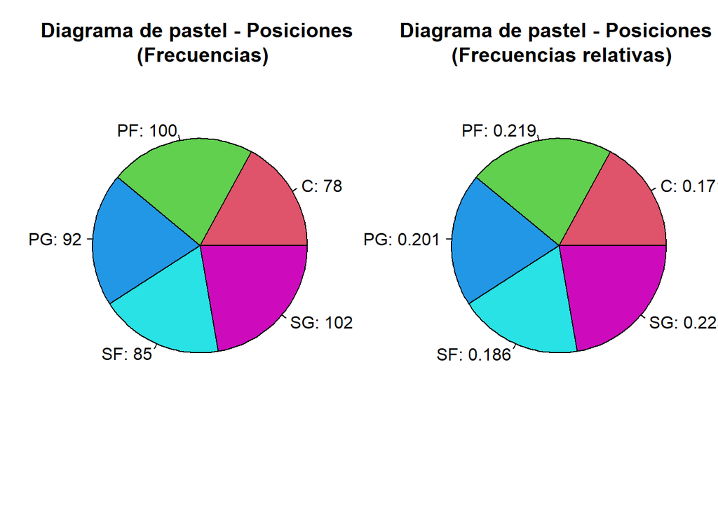

```r
# Diagrama Circular

par(mfrow=c(1,2))
pie(tabla_position$Freq,labels=paste(c("C","PF","PG","SF","SG"),tabla_position$Freq,sep=": "),col=2:7,radius=1)
title("Diagrama de pastel - Posiciones \n (Frecuencias)")

pie(tabla_position$Rel,labels=paste(c("C","PF","PG","SF","SG"),tabla_position$Rel,sep=": "),col=2:7,radius=1)
title("Diagrama de pastel - Posiciones \n (Frecuencias relativas)")
```

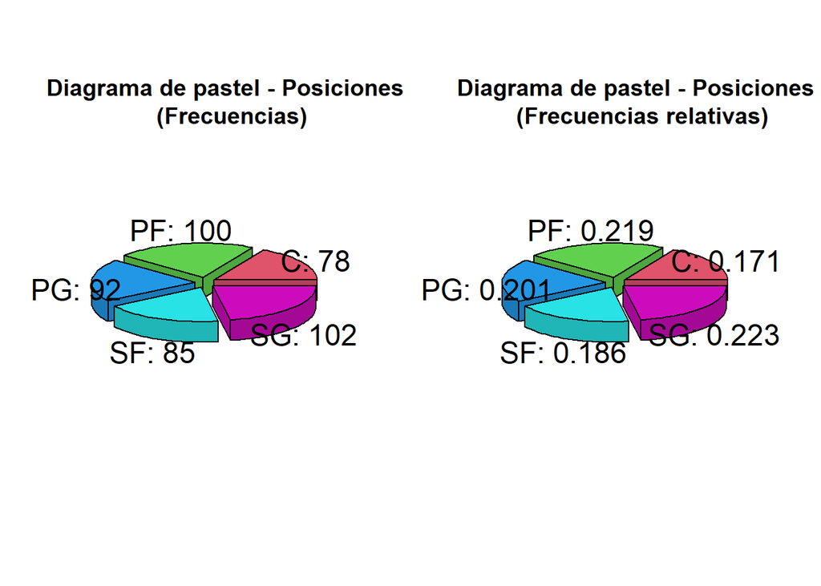

```r
library(plotrix)
par(mfrow=c(1,2))
pie3D(tabla_position$Freq,labels=paste(c("C","PF","PG","SF","SG"),tabla_position$Freq,sep=": "),col=2:7,explode = 0.1)
title("Diagrama de pastel - Posiciones \n (Frecuencias)")

pie3D(tabla_position$Rel,labels=paste(c("C","PF","PG","SF","SG"),tabla_position$Rel,sep=": "),col=2:7,explode = 0.1)
title("Diagrama de pastel - Posiciones \n (Frecuencias relativas)")
```

# 3 Análisis descriptivo de variables cuantitativas

# 4 El problema de comparación y asociación entre variables